[figure not shown]

# **GRASS GIS for remote sensing data processing and analysis**

### Workshop at FOSS4G 2022, Florence (Italy)

*Lecturers:* Veronica Andreo, Markus Neteler & Maris Nartiss

*Date:* 2022-08-23

### Foreword

This notebook will demonstrate the use of **GRASS GIS 8.2+** in combination with Python within a Jupyter Notebook environment. We will use GRASS modules and related python libraries that facilitate scripting (`grass.script`) and connection/interaction with Jupyter Notebooks (`grass.jupyter`).

The workflow that will be demonstrated on this notebook ranges from searching satellite data to time series building and supervised classification.

### Dependencies

Some Python dependencies are needed to run the proposed exercises of this notebook. Install as follows:

```python
!pip3 install sentinelsat notebook folium scikit-learn pandas numpy seaborn matplotlib ipywidgets
```

### Table of contents

1. Why Jupyter Notebooks and how to use them?
2. GRASS GIS basics
3. GRASS GIS & Python
4. Getting ready: set variables and download sample data
5. Initialization of GRASS GIS in the Jupyter notebook session
6. Creating an area of interest map
7. Importing geodata into GRASS GIS
8. Sentinel-2 processing overview
9. Computing NDVI
10. Time series data processing
11. Creating an image stack (imagery group)
12. Object recognition with image segmentation
13. Supervised Classification: Random Forest
14. Supervised Classification: Maximum Likelihood and band references
15. What’s next?

## 1. Why Jupyter Notebooks and how to use them?

Jupyter Notebooks are server-client applications that allow code written in a notebook document to be **edited and executed through a web browser**. They can be run on a local computer (no internet access required) or used to control computations on a remote server accessed via the Internet ([see the documentation](https://jupyter-notebook-beginner-guide.readthedocs.io/en/latest/what_is_jupyter.html)).

Jupyter Notebooks can be interactive and they allow to combine live code, explanatory text, and computational results in a single document. In general, they are:

- convenient for initial code development (prototyping)
- ideal for code segmentation with the ability to re-run cells
- able to store values of variables from already executed cells

The notebook can be saved as an executable Python script in addition to the native `.ipynb` format, or exported to various documentation formats such as PDF or Sphinx RST with nice styling.

#### Editing and interactive use

Editing a Jupyter Notebook is very easy: in the web browser, you can navigate between text or code cells using the mouse or keyboard shortcuts (see Menu > Help > Keyboard Shortcuts). You can execute small code chunks cell by cell, save the notebook in its current state, or modify and recalculate cells or return them to their previous state. In addition to executable code cells, you can use Markdown in documentation cells to make them presentable to others.

## 2. GRASS GIS basics

### Open GRASS for the first time

As of version 8.0, GRASS has modified its startup to make it more user friendly:

[figure not shown]

From the **Data** catalog tab you can manage several actions and if you do not yet have imported data into the GRASS database, the software creates the directory structure or database automatically.

### Database

- **GRASS database** (directory with projects): When running GRASS GIS for the first time, a folder named “grassdata” is automatically created. Depending on the operating system, it can be found in `$HOME` (*nix) or `My Documents` (MS Windows).
- **Location** (a project): A location is defined by its coordinate reference system (CRS). The location that is automatically created is in WGS84 (EPSG:4326). If you have data in another CRS, you should ideally create a new location.
- **Mapset** (a subproject): Each location can have many mapsets to manage different aspects or sub-regions of a project. When creating a new location, GRASS GIS automatically creates a special mapset called *PERMANENT* where the central data of the project (e.g., base maps, road network, dem, etc.) can be stored.

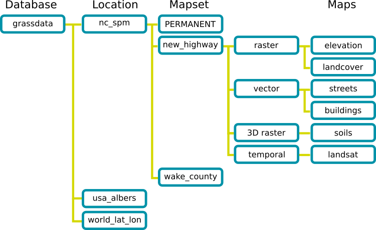

More info: https://grass.osgeo.org/grass-stable/manuals/grass_database.html.

### Computational region

Another fundamental concept of GRASS GIS (and very useful when working with raster data) is that of the **computational region**. It refers to the boundary configuration of the analysis area and spatial resolution (raster). The **computational region** can be defined and modified with the command [g.region](https://grass.osgeo.org/grass-stable/manuals/g.region.html) to the extent of a vector map, a raster or manually to some area of interest. The *output raster maps will have an extent and spatial resolution equal to the computational region*, while vector maps are always processed at their original extent.

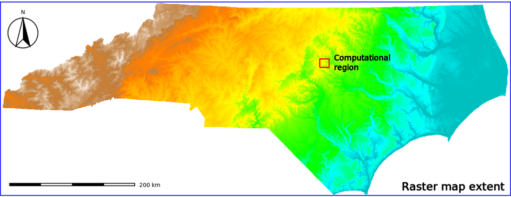

For more details, see the wiki on [Computational Region](https://grasswiki.osgeo.org/wiki/Computational_region).

### Modules and extensions

GRASS has more than [500 modules](https://grass.osgeo.org/grass-stable/manuals/full_index.html) for the most varied tasks:

| Prefix | Function class | Type of command | Example |
| --- | --- | --- | --- |
| [g.*](https://grass.osgeo.org/grass-stable/manuals/full_index.html#g) | general | general data management | [g.rename](https://grass.osgeo.org/grass-stable/manuals/g.rename.html): renames map |
| [d.*](https://grass.osgeo.org/grass-stable/manuals/full_index.html#d) | display | graphical output | [d.rast](https://grass.osgeo.org/grass-stable/manuals/d.rast.html): display raster map |
| [r.*](https://grass.osgeo.org/grass-stable/manuals/full_index.html#r) | raster | raster processing | [r.mapcalc](https://grass.osgeo.org/grass-stable/manuals/r.mapcalc.html): map algebra |
| [v.*](https://grass.osgeo.org/grass-stable/manuals/full_index.html#r) | vector | vector processing | [v.clean](https://grass.osgeo.org/grass-stable/manuals/v.clean.html): topological cleaning |
| [i.*](https://grass.osgeo.org/grass-stable/manuals/full_index.html#i) | imagery | imagery processing | [i.pca](https://grass.osgeo.org/grass-stable/manuals/i.pca.html): Principal Components Analysis on imagery group |
| [r3.*](https://grass.osgeo.org/grass-stable/manuals/full_index.html#r3) | voxel | 3D raster processing | [r3.stats](https://grass.osgeo.org/grass-stable/manuals/r3.stats.html): voxel statistics |
| [db.*](https://grass.osgeo.org/grass-stable/manuals/full_index.html#db) | database | database management | [db.select](https://grass.osgeo.org/grass-stable/manuals/db.select.html): select value(s) from table |
| [ps.*](https://grass.osgeo.org/grass-stable/manuals/full_index.html#ps) | postscript | PostScript map creation | [ps.map](https://grass.osgeo.org/grass-stable/manuals/ps.map.html): PostScript map creation |
| [t.*](https://grass.osgeo.org/grass-stable/manuals/full_index.html#t) | temporal | space-time datasets | [t.rast.aggregate](https://grass.osgeo.org/grass-stable/manuals/t.rast.aggregate.html): raster time series aggregation |

Extensions or **add-ons** can be installed from the [central GitHub repository](https://grass.osgeo.org/grass-stable/manuals/addons/) or from *other users’ GitHub* (or similar repositories) using the command [g.extension](https://grass.osgeo.org/grass-stable/manuals/g.extension.html). For example:

```bash
 # install an extension from the GRASS GIS repository
 g.extension extension=r.hants

 # install an extension from another GitHub repository
 g.extension extension=r.change.stats \
   url=https://github.com/mundialis/r.change.stats
```

## 3. GRASS & Python

### Python package `grass.script`

The **grass.script** or GRASS GIS Python Scripting Library provides functions for calling GRASS modules within Python scripts. The most commonly used functions include:

- `run_command`: used when the output of the modules is a raster or vector, no text type output is expected
- `read_command`: used when the output of the modules is of text type
- `parse_command`: used with modules whose output can be converted to `key=value` pairs
- `write_command`: used with modules that expect text input, either in the form of a file or from stdin

It also provides several wrapper functions for frequently used modules, for example:

- To get info from a raster, script.raster.raster_info() is used: `gs.raster_info('dsm')`
- To get info of a vector, script.vector.vector_info() is used: `gs.vector_info('roads')`
- To list the raster in a location, script.core.list_grouped() is used: `gs.list_grouped(type=['raster'])`
- To obtain the computational region, script.core.region() is used: `gs.region()`

More info: https://grass.osgeo.org/grass-stable/manuals/libpython/script_intro.html

### Python package `grass.jupyter`

The **grass.jupyter** library improves the integration of GRASS and Jupyter, and provides different classes to facilitate GRASS maps visualization:

- `init`: starts a GRASS session and sets up all necessary environment variables
- `Map`: 2D rendering
- `Map3D`: 3D rendering
- `InteractiveMap`: interactive visualization with folium
- `TimeSeriesMap`: visualization for spatio-temporal data

More info: https://grass.osgeo.org/grass-stable/manuals/libpython/grass.jupyter.html

## 4. Getting ready: set variables and download sample data

For the ease of working in this notebook, we define some session variables.

```python
import os

# data directory
homedir = os.path.join(os.path.expanduser('~'), "foss4g_grass4rs")

# GRASS GIS database variables
#grassbin = "grassdev"
grassbin = "grass"
grassdata = os.path.join(homedir, "grassdata")
location = "nc_spm_08_grass7"
mapset = "PERMANENT"
```

```python
# Sentinel-2 related directories
s2_data = os.path.join(homedir, "sentinel")
s2_timestamps = os.path.join(homedir, s2_data, "sentinel-timestamps.txt")

# create directories if not already existing
os.makedirs(grassdata, exist_ok=True)
os.makedirs(s2_data, exist_ok=True)

# the variables are also accessible via Python
print(homedir)

# list content
os.listdir(homedir)
```

Next we check the GRASS GIS installation:

```python
import subprocess
print(subprocess.check_output([grassbin, "--config", "version"], text=True))
```

Next, if not already there, we download **North Carolina location** and unpack it within the above defined `homedir`.

```python
# download NC sample data into target directory homedir (we use `wget` on command line here)
!wget -c https://grass.osgeo.org/sampledata/north_carolina/nc_spm_08_grass7.zip -O $homedir/nc.zip
```

```python
# unpack sample dataset into target directory homedir
!unzip -o -q -d $grassdata $homedir/nc.zip

print("List uploaded file(s) in target directory "+homedir+":")
os.listdir(homedir)
```

Download and unzip Sentinel-2 scenes:

```python
# download Sentinel-2 data into target directory homedir
!wget -c https://data.neteler.org/foss4g2022/sentinel.zip -O $homedir/sentinel.zip

# unpack into target directory homedir
!unzip -o -q -d $homedir $homedir/sentinel.zip
```

Download landuse map:

```python
# get NC landuse map 2019 in GRASS GIS format, to be used later as classification training map
!wget -c https://data.neteler.org/foss4g2022/nc_nlcd2019.pack -O $homedir/nc_nlcd2019.pack
```

```python
print("List uploaded file(s) in target directory "+homedir+":")
os.listdir(homedir)
```

## 5. Imports and initialization of GRASS GIS

```python
# Import standard Python packages we need
import sys

# Ask GRASS GIS where its Python packages are to be able to run it from the notebook
sys.path.append(
    subprocess.check_output([grassbin, "--config", "python_path"], text=True).strip()
)
```

```python
# Import the GRASS GIS packages we need
import grass.script as gs
import grass.jupyter as gj

# Start the GRASS GIS Session
session = gj.init(grassdata, location, mapset)
```

```python
# Show current GRASS GIS settings, this also checks if the session works
gs.gisenv()
```

```python
# List vector elements in the PERMANENT mapset
gs.list_grouped(type="vector")
```

Now we import the landuse map into the PERMANENT mapset (so it is visible in all other mapsets).

```python
## Import of the North Carolina NLCD2019 raster map (subset; resampled to 10m)
gs.run_command("r.unpack", input=os.path.join(homedir, "nc_nlcd2019.pack"))
```

```python
# show metadata
print(gs.read_command("r.report", map="nc_nlcd2019"))
```

Next, we create a new mapset or project, where we will work with this notebook and import Sentinel-2 data.

```python
# Create a new mapset and switch to it
gs.run_command("g.mapset", mapset="sentinel2", flags="c")
```

```python
# Another way would be to use the grass.grassdb functions:

# import grass.grassdb.create as gsdb
# gsdb.create_mapset(grassdata, location, "sentinel2")
# session.switch_mapset("sentinel2")
```

```python
# Check current mapset
print(gs.read_command("g.mapset", flags="p"))
```

```python
# Print accessible mapsets within the location
print(gs.read_command("g.mapsets", flags="p"))
```

## 6. Creating an area of interest map

To search for Sentinel 2 images, we need an area of interest. This area can be defined by a vector map or the computational region. Here, will use a map of urban areas that we already have in the PERMANENT mapset to define the region. Since we are interested in the city of Raleigh, we use the function [v.extract](https://grass.osgeo.org/grass-stable/manuals/v.extract.html) to create a new polygon corresponding to that urban area only. Note that in this case we use `run_command()`.

```python
# Check `urbanarea` vector attributes
gs.vector_db_select('urbanarea')['values']
```

```python
# Extract Raleigh urban area from `urbanarea` vector map
gs.run_command("v.extract",
               input="urbanarea",
               where="NAME == 'Raleigh'",
               output="urban_area_raleigh")
```

```python
# show attributes
gs.vector_db_select('urban_area_raleigh')['values']
```

We set the computational region to the boundaries of the newly created vector. This will be the bounding box we’ll use for the Sentinel scenes search.

```python
# Set the computational region to the extent of Cordoba urban area
region = gs.parse_command("g.region", vector="urban_area_raleigh", flags="g")
region
```

We now use the `grass.jupyter` functions to display the newly obtained vector over the OpenStreetMap basemap.

```python
# Display newly created vector
raleigh_map = gj.InteractiveMap(width = 500, use_region=True, tiles="OpenStreetMap")
raleigh_map.add_vector("urban_area_raleigh")
raleigh_map.add_layer_control(position = "bottomright")
raleigh_map.show()
```

## 7. Sentinel-2 processing overview

There are plenty of libraries or tools which allow downloading Sentinel products from [Copernicus Open Access Hub](https://scihub.copernicus.eu/).

For GRASS GIS there is the [i.sentinel](https://grass.osgeo.org/grass-stable/manuals/addons/i.sentinel.html) toolbox that facilitates searching, filtering, downloading, importing and pre-processing Sentinel data, especially Sentinel 2, from a GRASS GIS session. The toolbox consists of six GRASS addon modules:

- [i.sentinel.download](https://grass.osgeo.org/grass-stable/manuals/addons/i.sentinel.download.html)
- [i.sentinel.import](https://grass.osgeo.org/grass-stable/manuals/addons/i.sentinel.import.html)
- [i.sentinel.preproc](https://grass.osgeo.org/grass-stable/manuals/addons/i.sentinel.preproc.html)
- [i.sentinel.mask](https://grass.osgeo.org/grass-stable/manuals/addons/i.sentinel.mask.html)
- [i.sentinel.coverage](https://grass.osgeo.org/grass-stable/manuals/addons/i.sentinel.coverage.html)
- [i.sentinel.parallel.download](https://grass.osgeo.org/grass-stable/manuals/addons/i.sentinel.parallel.download.html)

Let’s install it:

```python
gs.run_command("g.extension", extension="i.sentinel")
```

Check if the module is there by running it with optional arguments:

```python
gs.core.find_program("i.sentinel.download", "--help")
```

### Sentinel 2 data search and download

[Sentinel-2 L2A products](https://sentinels.copernicus.eu/de/web/sentinel/user-guides/sentinel-2-msi/product-types/level-2a) will be used to avoid the need of computing atmospheric corrections.

Let’s search for the latest available product by means of [i.sentinel.download](https://grass.osgeo.org/grass-stable/manuals/addons/i.sentinel.download.html). Setting the `-l` flag, the result will only be printed. The download procedure will be demonstrated later.

In order to search and download Sentinel products from the Copernicus Open Access Hub, you have to create an account first (see below). See the manual page of [i.sentinel.download](https://grass.osgeo.org/grass-stable/manuals/addons/i.sentinel.download.html) module for details. Upload or create a new text file in the data directory (`homedir`) named `esa_credentials.txt` containing two lines: username and password.

#### Note

To get username and password you need to register at the [Copernicus Open Access Hub](https://scihub.copernicus.eu/), see the [register new account](https://scihub.copernicus.eu/dhus/#/self-registration) page for signing up. Once you registered, create a text file named `esa_credentials.txt` with the following content:

```
    username
    password
```

and move it within your working directory

```python
# list available Sentinel-2 L2A scenes for AOI
# note that we use parse_command() in order to intercept the output
gs.parse_command("i.sentinel.download",
                 flags="l",
                 producttype="S2MSI2A",
                 map="urban_area_raleigh",
                 settings=os.path.join(homedir, "esa_credentials.txt"))
```

By default, the module returns all the products meeting the defined criteria for the last 60 days. Let’s change the search period setting `start` and `end` options. We will also limit products by `clouds` coverage percentage threshold and `sort` them by ingestion date.

```python
gs.parse_command("i.sentinel.download",
                 flags="l",
                 producttype="S2MSI2A",
                 map="urban_area_raleigh",
                 settings=os.path.join(homedir, "esa_credentials.txt"),
                 start="2022-02-01",
                 end="2022-05-31",
                 clouds="5",
                 sort="ingestiondate",
                 limit=10)
```

If a long list of products have been found, you can limit the amount with the `limit` option as we did above.

Let’s save the output of the search into a list and then beautify the display by creating a pandas table.

```python
list_prod = gs.read_command("i.sentinel.download",
                            flags="l",
                            producttype="S2MSI2A",
                            map="urban_area_raleigh",
                            settings=os.path.join(homedir, "esa_credentials.txt"),
                            footprints="s2_footprints", # we save the footprints in a vector file
                            start="2022-02-01",
                            end="2022-05-31",
                            clouds="5",
                            sort="ingestiondate",
                            limit=10)
```

```python
# print plain list
list_prod
```

```python
import pandas as pd
from io import StringIO

pd.read_csv(StringIO(list_prod), delimiter=" ", usecols=[0, 1, 2, 4, 5, 6, 7],
            names=['uuid', 'scene', 'date', 'cloud', 'product', 'size', 'unit'])
```

```python
# list available vector maps in sentinel2
gs.list_grouped(type="vector")["sentinel2"]
```

```python
# diplay footprints (you may want to zoom out a bit)
fp_map = gj.InteractiveMap(width = 400, use_region=True, tiles="OpenStreetMap")
fp_map.add_vector("s2_footprints")
fp_map.add_vector("urban_area_raleigh")
fp_map.add_layer_control(position = "bottomright")
fp_map.show()
```

The next step is to download the scene or scenes of interest. Just remove the `-l` flag and add the `output` option in order to define the path to the output directory where data should be saved.

As download might take quite some time, we’ll **skip this part** and directly use an already prepared set of smaller, ready to import scenes which we downloaded above. Still, we leave an example below for future reference :)

Go to section **“Importing Sentinel 2 data”**

```python
# Example: download of a selected scene (2022-06-17, T15:58:29Z)
# gs.run_command("i.sentinel.download",
#               settings=s2_credentials,
#               uuid="cfa30609-5627-4788-b7ff-768e2df99975",
#               output=s2_data)
```